# Units Movement

We’ll pick up where we left off with the player units in this lesson: coding movement around the ship. We need to code an appropriate unit path following strategy to move from room-to-room instead of tile-to-tile.

These units have to move within valid positions in our ship.

We start by defining the problem we want to solve so that we can figure out our next steps:

- We use a

[figure not shown]

  `TileMap` as the underlying representation for our ship.
- We also would like the units to move around the ship to any room selected by the player.

Here are our requirements for movement:

1. Units should cross through doors when moving between rooms.
2. Units shouldn’t move to the same cell if moving all to the same room.
3. Units should follow the fastest path to the destination. For example, if we have a room with more than one door, the units should pick the door that allows for the fastest path to the destination tile.

## Pathfinding with AStar

Let’s start with finding the shortest path between two cells in the ship.

Godot comes with an `AStar2D` class designed to simplify this step. AStar is a well-known pathfinding algorithm that Godot provides out of the box, so we don’t have to reimplement it ourselves.

Open the `ShipTemplate.tscn` scene file and add a script to

[figure not shown]

`TileMap`. Save it as `res://TacticalSpaceCombat/Ship/TileMap.gd`:

We define a couple of variables, one for the `AStar2D` algorithm and the other, `_size`, to keep track of the size of the

[figure not shown]

`TileMap` for easy access. The size is provided to us by the

[figure not shown]

`TileMap` class.

```
extends TileMap

var _astar: AStar2D = AStar2D.new()
var _size: Vector2 = Vector2.ZERO
```

We define the `setup()` function next. We’ll call it from the ship’s `_ready()` function, so we need to move the `update_bitmask_region()` call from one of our previous lessons here instead.

Remove the line `tilemap.update_bitmask_region()` from `ShipTemplate.gd` and define the `setup()` function in the `Ship/TileMap.gd` script.

It takes a reference to the ship’s *Rooms* and *Doors* nodes and sets up the AStar graph.

The AStar algorithm works with a graph of connected points. We need to assign a unique ID to each point in the graph as well as its coordinates.

Here, the points are our ship’s walkable cells.

```
func setup(rooms: Node2D, doors: Node2D) -> void:
    update_bitmask_region()

    # We store the size of the `TileMap` in a global variable for easy access.
    # It's a size in cells.
    _size = get_used_rect().size

    # This loop detects and connects all the points inside each room, but not
    # across rooms.
    for room in rooms.get_children():
        # We iterate over the points using our custom `Room` iterator.
        for point in room:
            # We convert each point from `Vector2(x, y)` coordinates into a unique index
            # using `Utils.xy_to_index()`. This conversion requires the width of the
            # `TileMap` which we get from `_size.x`
            var id := Utils.xy_to_index(_size.x, point)
            # We add the point and its unique ID to the AStar graph.
            _astar.add_point(id, point)
            # For each valid `neighbor` position, we add it to the `AStar2D`
            # algorithm and connect it with the current `point` via its `id`.
            for neighbor in _get_neighbors(room, point):
                var neighbor_id := Utils.xy_to_index(_size.x, neighbor)
                _astar.add_point(neighbor_id, neighbor)
                _astar.connect_points(id, neighbor_id)
```

There’s a `_get_neighbors()` function we need to define next. It returns an

[figure not shown]

`Array` of valid neighbor positions within a given room around a given cell.

To code it, we’ll first define a list of 8 directions as a constant. As this is one we’ll reuse later, we add it to `Utils.gd`:

```
# A list of 8 directions: horizontal, vertical, and diagonal.
const DIRECTIONS := [
    Vector2.UP,
    Vector2.RIGHT + Vector2.UP,
    Vector2.RIGHT,
    Vector2.RIGHT + Vector2.DOWN,
    Vector2.DOWN,
    Vector2.LEFT + Vector2.DOWN,
    Vector2.LEFT,
    Vector2.LEFT + Vector2.UP
]
```

We head back to `TileMap.gd` and add `_get_neighbors()`.

```
## Returns neighboring positions within a `room` given the input `point` location.
func _get_neighbors(room: Room, point: Vector2) -> Array:
    var out := []
    # We traverse the list of valid `DIRECTIONS` defined in our `Utils` class.
    for offset in Utils.DIRECTIONS:
        # Since these are directions, we first need to add them to the position of
        # the `point` location.
        offset += point
        # We have yet to define this function, we'll do it in a second.
        if room.has_point(offset):
            # In case the `room` contains the calculated position, it means it's a valid
            # neighboring tile so we add it to the array.
            out.push_back(offset)
    return out
```

```
## Checks if the given point is within the bounds of the room
func has_point(point: Vector2) -> bool:
    return Rect2(_top_left, size).has_point(point)
```

At this point, we can find a path inside each room, but we’re missing connections across rooms. So we head back to `TileMap.gd` and add the following lines at the end of the `setup()` function to connect rooms through doors.

```
func setup(rooms: Node2D, doors: Node2D) -> void:
    #...

    # Here, we connect rooms through doors. Doors are between two cells, so we
    # need to offset their position by half a cell forward and backward, based
    # on their position and orientation, to find their neighbors.
    # I explain how this works in greater detail below.
    var offset := cell_size / 2 * Vector2.UP
    for door in doors.get_children():
        # We use the door's transform to apply the offset forward and backward,
        # based on the door's orientation.
        #
        # The `Transform2D.xform()` method applies the node's transform to the
        # passed vector.
        #
        # In other words, it applies the position, rotation, and scale of each
        # door to the `offset` vector, making it point to the cells facing each
        # door.
        var id1 := Utils.xy_to_index(_size.x, world_to_map(door.transform.xform(offset)))
        var id2 := Utils.xy_to_index(_size.x, world_to_map(door.transform.xform(-offset)))
        _astar.connect_points(id1, id2)
```

### How we connect rooms through doors

Calculating valid tile positions on each side of the doors from separate rooms requires an explanation.

For each door, we need to calculate two locations like in the following image.

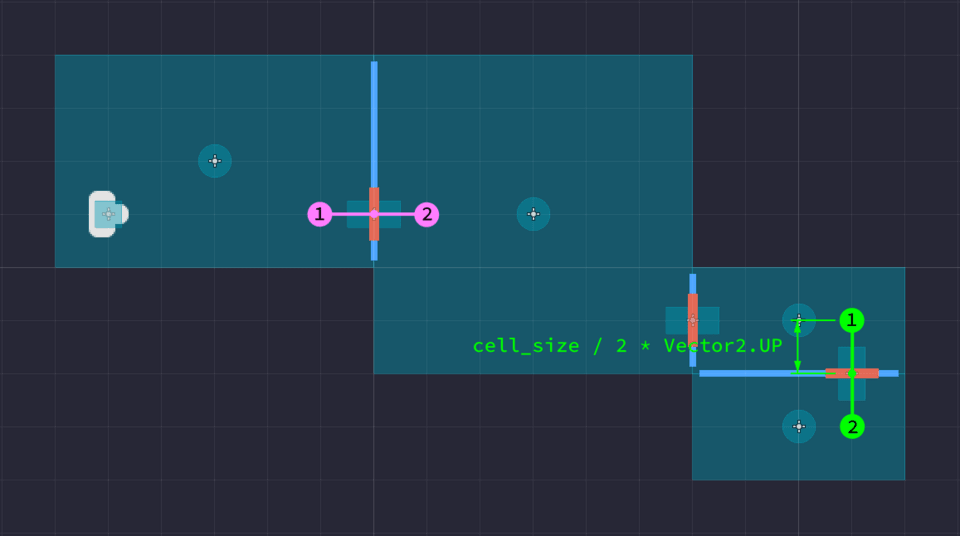

In the green case (horizontal door), the *Door* isn’t rotated, while in the purple case (vertical door), the door is rotated `90` degrees from its original orientation.

`offset` is a

[figure not shown]

`Vector2` from door to the center of the neighboring top tile (1).

We can get the

[figure not shown]

`Vector2` pointing from the same door to the neighboring bottom tile (2) with `-offset`.

Since `offset` is a

[figure not shown]

`Vector2` **relative to a non-rotated** door, we’ll have to take the door’s orientation into account.

This sounds complicated, but the `Transform2D.xform()` method does it for us: it moves and rotates the vector we give it based on the node’s current transform.

*Note* that all

[figure not shown]

`Node2D` nodes have a `transform` property representing their transform matrix (position, rotation, and scale relative to their parent).

Now, we need to convert these positions into

[figure not shown]

`TileMap` coordinates which we achieve with the `world_to_map()` method.

At the end, we convert these positions into 1D indices with `Utils.xy_to_index()` and connect them with `_astar.connect_points(id1, id2)`.

This is how we bridge neighboring tiles from different rooms into our `AStar2D` algorithm.

## Finding a path between two rooms

We can now write a function to find a path between two cells on the ship. We’ll name it `find_path()` and have it return a

[figure not shown]

`Curve2D` ready for assignment to the unit’s *Path2D*’s `curve` property. This will, in turn, allow us to move units smoothly along the path.

```
## Finds a path between two cells using AStar and returns a `Curve2D` for units to follow.
func find_path(point1: Vector2, point2: Vector2) -> Curve2D:
    var out := Curve2D.new()
    # Given the two points we first calculate the 1D index IDs
    var id1 := Utils.xy_to_index(_size.x, point1)
    var id2 := Utils.xy_to_index(_size.x, point2)
    if _astar.has_point(id1) and _astar.has_point(id2):
        # If these are valid points in our `AStar2D` object then we
        # get the `path` between these points
        var path := _astar.get_point_path(id1, id2)
        # We drop the first point in `path` because that's the location of the tile
        # the unit is in, but we'd like to add the location of the unit instead.
        # That's because if the unit is already moving, we don't want it to jump to the
        # tile first before starting to move again.
        #
        # We make sure to convert to world coordinates considering the centers of
        # the tiles.
        for i in range(1, path.size()):
            out.add_point(map_to_world(path[i]) + cell_size / 2)
    return out
```

Before moving on to the unit movement, we need to add two things to `ShipTemplate.gd`:

- A reference to the ship’s *Doors* node.
- A call to our tilemap’s `setup()` function.

Open `ShipTemplate.gd` and update the code like so:

```
# ...
onready var doors: Node2D = $Doors

func _ready_not_editor_hint() -> void:
    # ...
    # We set up our tilemap's astar graph at the end of the function.
    tilemap.setup(rooms, doors)
```

We can now test everything works with some temporary code. At the end of `_ready_not_editor_hint()`, we can call `tilemap.find_path()` with two cells. Note they must exist on the ship for this to work.

```
func _ready_not_editor_hint() -> void:
    # ...
    # The path is a Curve2D object.
    var path: Curve2D = tilemap.find_path(
        Vector2(0, 0),
        Vector2(4, 2)
    )
    print(path.get_baked_points())
```

If both input coordinates exist, you should see a long list of coordinates in the output.

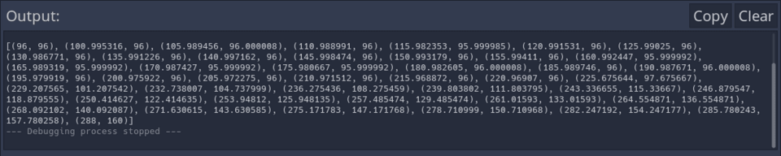

That’s because curves precalculate and cache intermediate vertices, creating many more points than cells in our ship. However, you don’t have to worry about this: it’s fast and will give us free smooth movement in our final ship.

You can remove that test code before moving on. In the next part, we’ll let the player move units around the ship.

## Code reference

`TacticalSpaceCombat/Ship/ShipTemplate.gd`:

```
tool
extends Node2D

onready var tilemap: TileMap = $TileMap
onready var rooms: Node2D = $Rooms
onready var units: Node2D = $Units
onready var doors: Node2D = $Doors


func _ready() -> void:
    call("_ready_editor_hint" if Engine.editor_hint else "_ready_not_editor_hint")


func _ready_editor_hint() -> void:
    for room in rooms.get_children():
        room.setup(tilemap)


func _ready_not_editor_hint() -> void:
    for room in rooms.get_children():
        room.setup(tilemap)

        for point in room:
            tilemap.set_cellv(point, 0)
    tilemap.setup(rooms, doors)
    var path: Curve2D = tilemap.find_path(
        Vector2(0, 0),
        Vector2(4, 2)
    )
    print(path.get_baked_points())
```

`TacticalSpaceCombat/Ship/TileMap.gd`:

```
extends TileMap

var _astar: AStar2D = AStar2D.new()
var _size: Vector2 = Vector2.ZERO


func setup(rooms: Node2D, doors: Node2D) -> void:
    update_bitmask_region()

    _size = get_used_rect().size

    for room in rooms.get_children():
        for point in room:
            var id := Utils.xy_to_index(_size.x, point)
            _astar.add_point(id, point)
            for neighbor in _get_neighbors(room, point):
                var neighbor_id := Utils.xy_to_index(_size.x, neighbor)
                _astar.add_point(neighbor_id, neighbor)
                _astar.connect_points(id, neighbor_id)

    var offset := cell_size / 2 * Vector2.UP
    for door in doors.get_children():
        var id1 := Utils.xy_to_index(_size.x, world_to_map(door.transform.xform(offset)))
        var id2 := Utils.xy_to_index(_size.x, world_to_map(door.transform.xform(-offset)))
        _astar.connect_points(id1, id2)


func find_path(point1: Vector2, point2: Vector2) -> Curve2D:
    var out := Curve2D.new()
    var id1 := Utils.xy_to_index(_size.x, point1)
    var id2 := Utils.xy_to_index(_size.x, point2)
    if _astar.has_point(id1) and _astar.has_point(id2):
        var path := _astar.get_point_path(id1, id2)
        for i in range(1, path.size()):
            out.add_point(map_to_world(path[i]) + cell_size / 2)
    return out


func _get_neighbors(room: Room, point: Vector2) -> Array:
    var out := []
    for offset in Utils.DIRECTIONS:
        offset += point
        if room.has_point(offset):
            out.push_back(offset)
    return out
```

`res://TacticalSpaceCombat/Utils.gd`:

```
class_name Utils

const DIRECTIONS := [
    Vector2.UP,
    Vector2.RIGHT + Vector2.UP,
    Vector2.RIGHT,
    Vector2.RIGHT + Vector2.DOWN,
    Vector2.DOWN,
    Vector2.LEFT + Vector2.DOWN,
    Vector2.LEFT,
    Vector2.LEFT + Vector2.UP
]

## Converts `offset` coordinates to an integer index.
static func xy_to_index(width: int, offset: Vector2) -> int:
    return int(offset.x + width * offset.y)

## Converts an integer `index` to `Vector2(x, y)` coordinates.
static func index_to_xy(width: int, index: int) -> Vector2:
    return Vector2(index % width, index / width)
```

`res://TacticalSpaceCombat/Ship/Rooms/Room.gd`:

```
tool
class_name Room
extends Area2D

export var size := Vector2.ONE setget set_size

var _area := 0
var _top_left := Vector2.ZERO
var _bottom_right := Vector2.ZERO
var _iter_index := 0

var _tilemap: TileMap = null

onready var collision_shape: CollisionShape2D = $CollisionShape2D
onready var feedback: NinePatchRect = $Feedback


func setup(tilemap: TileMap) -> void:
    _tilemap = tilemap
    _setup_extents()
    _area = size.x * size.y
    _top_left = _tilemap.world_to_map(position - collision_shape.shape.extents)
    _bottom_right = _top_left + size

    feedback.rect_position -= collision_shape.shape.extents
    feedback.rect_size = 2 * collision_shape.shape.extents


func _setup_extents() -> void:
    if _tilemap != null:
        collision_shape.shape.extents = 0.5 * _tilemap.map_to_world(size)


func _ready() -> void:
    connect("mouse_entered", self, "_on_mouse_entered_exited", [true])
    connect("mouse_exited", self, "_on_mouse_entered_exited", [false])


func has_point(point: Vector2) -> bool:
    return Rect2(_top_left, size).has_point(point)


func set_size(value: Vector2) -> void:
    for axis in [Vector2.AXIS_X, Vector2.AXIS_Y]:
        size[axis] = max(1, value[axis])
    _setup_extents()


func _iter_init(_arg) -> bool:
    _iter_index = 0
    return _iter_is_running()


func _iter_next(_arg) -> bool:
    _iter_index += 1
    return _iter_is_running()


func _iter_get(_arg) -> Vector2:
    var offset := Utils.index_to_xy(size.x, _iter_index)
    return _top_left + offset


func _iter_is_running() -> bool:
    return _iter_index < _area


func _on_mouse_entered_exited(has_entered: bool) -> void:
    feedback.visible = has_entered

    var group := "selected-room"
    if has_entered:
        add_to_group(group)
    elif is_in_group(group):
        remove_from_group(group)
```